# Taller de Analisis Exploratorio de Datos

Mariana Mendez y Claret Rodriguez

2025-12-04

# 1 Introducción al Taller

## 1.1 Objetivo General

En este taller práctico, se trabajará con un conjunto de datos real que contiene registros académicos de 2000 estudiantes. El estudiante aprenderá a realizar un Análisis Exploratorio de Datos (EDA) utilizando R Studio, desde la importación de datos hasta la construcción de un modelo de regresión lineal simple.

## 1.2 ¿Qué es el EDA?

El Análisis Exploratorio de Datos (EDA) es el proceso de examinar y resumir las características principales de un conjunto de datos con el fin de:

- Comprender la estructura y contenido de los datos
- Detectar errores, valores faltantes o atípicos
- Calcular estadísticas descriptivas
- Visualizar patrones mediante gráficos
- Verificar supuestos estadísticos
- Identificar relaciones entre variables

## 1.3 Objetivos Específicos

1. Importar y explorar datos en R Studio
2. Calcular medidas de tendencia central y dispersión
3. Crear gráficos estadísticos
4. Evaluar la normalidad de una variable
5. Analizar correlación entre dos variables
6. Construir un modelo de regresión lineal simple

## 1.4 Modalidad de Trabajo

- Modalidad: Individual o en parejas
- Herramienta: R Studio
- Duración estimada: 2-3 horas
- Entregable: Script de R (.R) con todos los análisis

# 2 Descripción del Conjunto de Datos

## 2.1 Contexto del Dataset

El dataset “Student Performance Prediction” fue obtenido de Kaggle y contiene información académica de 2000 estudiantes.

## 2.2 Variables del Dataset

- Student ID
- Attendance Rate
- Internal Test 1
- Internal Test 2
- Assignment Avg
- Study Hours Per Day
- Final Exam Mark

## 2.3 Flujo del Análisis EDA

1. Importación de datos
2. Exploración inicial
3. Limpieza de datos
4. Estadística descriptiva
5. Visualización
6. Normalidad
7. Correlación
8. Regresión lineal

# 3 Configuración del Entorno de Trabajo

## 3.1 Instalación de Paquetes

```r
install.packages("ggplot2")
install.packages("dplyr")
install.packages("corrplot")
install.packages("reshape2")
```

## 3.2 Cargar las Librerías

```r
library(ggplot2)
library(dplyr)
library(corrplot)
library(reshape2)
```

## 3.3 Importar el Dataset

```r
datos <- read.csv("C:/Users/mari2/Desktop/Calificaciones.csv")
cat("El dataset tiene", nrow(datos), "filas y", ncol(datos), "columnas\n")
```

```
## El dataset tiene 2000 filas y 7 columnas
```

### Actividad

El dataset tiene 2000 filas y 7 columnas

# 4 Exploración Inicial de los Datos

## 4.1 Primeras y Últimas Filas

```r
head(datos)
```

```
##   Student_ID Attendance.... Internal.Test.1..out.of.40.
## 1      S1000             84                          30
## 2      S1001             91                          24
## 3      S1002             73                          29
## 4      S1003             80                          36
## 5      S1004             84                          31
## 6      S1005            100                          34
##   Internal.Test.2..out.of.40. Assignment.Score..out.of.10. Daily.Study.Hours
## 1                          36                            7                 3
## 2                          38                            6                 3
## 3                          26                            7                 3
## 4                          35                            7                 3
## 5                          37                            8                 3
## 6                          34                            7                 3
##   Final.Exam.Marks..out.of.100.
## 1                            72
## 2                            56
## 3                            56
## 4                            74
## 5                            66
## 6                            79
```

```r
tail(datos)
```

```
##      Student_ID Attendance.... Internal.Test.1..out.of.40.
## 1995      S2994             97                          40
## 1996      S2995             82                          31
## 1997      S2996             78                          38
## 1998      S2997             78                          30
## 1999      S2998             82                          29
## 2000      S2999             97                          32
##      Internal.Test.2..out.of.40. Assignment.Score..out.of.10. Daily.Study.Hours
## 1995                          38                            9                 4
## 1996                          28                            6                 2
## 1997                          27                            7                 2
## 1998                          33                            9                 2
## 1999                          40                            8                 3
## 2000                          38                            7                 3
##      Final.Exam.Marks..out.of.100.
## 1995                            81
## 1996                            52
## 1997                            57
## 1998                            61
## 1999                            59
## 2000                            64
```

## 4.2 Estructura del Dataset

```r
str(datos)
```

```
## 'data.frame':    2000 obs. of  7 variables:
##  $ Student_ID                   : chr  "S1000" "S1001" "S1002" "S1003" ...
##  $ Attendance....               : int  84 91 73 80 84 100 96 83 91 87 ...
##  $ Internal.Test.1..out.of.40.  : int  30 24 29 36 31 34 40 39 30 27 ...
##  $ Internal.Test.2..out.of.40.  : int  36 38 26 35 37 34 36 37 37 37 ...
##  $ Assignment.Score..out.of.10. : int  7 6 7 7 8 7 8 7 8 8 ...
##  $ Daily.Study.Hours            : int  3 3 3 3 3 3 3 3 2 3 ...
##  $ Final.Exam.Marks..out.of.100.: int  72 56 56 74 66 79 83 77 71 61 ...
```

```r
names(datos)
```

```
## [1] "Student_ID"                    "Attendance...."
## [3] "Internal.Test.1..out.of.40."   "Internal.Test.2..out.of.40."
## [5] "Assignment.Score..out.of.10."  "Daily.Study.Hours"
## [7] "Final.Exam.Marks..out.of.100."
```

### Actividad

¿Cuantas variables numericas existen?

Exisiten seis variables numericas

¿Existe alguna variable de tipo texto (character)?

El dataset tiene una variable de tipo texto: Student_ID

## 4.3 Resumen Estadístico

```r
summary(datos)
```

```
##   Student_ID        Attendance....   Internal.Test.1..out.of.40.
##  Length:2000        Min.   : 52.00   Min.   :18.00
##  Class :character   1st Qu.: 80.00   1st Qu.:29.00
##  Mode  :character   Median : 85.00   Median :32.00
##                     Mean   : 84.89   Mean   :32.12
##                     3rd Qu.: 90.00   3rd Qu.:35.00
##                     Max.   :100.00   Max.   :40.00
##  Internal.Test.2..out.of.40. Assignment.Score..out.of.10. Daily.Study.Hours
##  Min.   :16.00               Min.   : 4.000               Min.   :1.000
##  1st Qu.:29.00               1st Qu.: 7.000               1st Qu.:2.000
##  Median :33.00               Median : 8.000               Median :3.000
##  Mean   :32.46               Mean   : 7.507               Mean   :2.824
##  3rd Qu.:36.00               3rd Qu.: 8.000               3rd Qu.:3.000
##  Max.   :40.00               Max.   :10.000               Max.   :5.000
##  Final.Exam.Marks..out.of.100.
##  Min.   : 25.00
##  1st Qu.: 58.00
##  Median : 65.00
##  Mean   : 64.86
##  3rd Qu.: 73.00
##  Max.   :100.00
```

### Actividad

Con el resultado de summary(datos), se deben anotar los valores para la variable Final Exam Mark:

Mínimo: 25.00

Máximo: 100.00

Mediana: 65.00

Media: 64.86

# 5 Limpieza y Preparación de Datos

## 5.1 Renombrar las Columnas

```r
colnames(datos) <- c(
  "ID",
  "Asistencia",
  "Examen_Interno_1",
  "Examen_Interno_2",
  "Promedio_Tareas",
  "Horas_Estudio",
  "Nota_Final"
)
names(datos)
```

```
## [1] "ID"               "Asistencia"       "Examen_Interno_1" "Examen_Interno_2"
## [5] "Promedio_Tareas"  "Horas_Estudio"    "Nota_Final"
```

## 5.2 Valores Faltantes

```r
colSums(is.na(datos))
```

```
##               ID       Asistencia Examen_Interno_1 Examen_Interno_2
##                0                0                0                0
##  Promedio_Tareas    Horas_Estudio       Nota_Final
##                0                0                0
```

```r
cat("Total de valores faltantes:", sum(is.na(datos)), "\n")
```

```
## Total de valores faltantes: 0
```

### Actividad

¿Existen valores faltantes en el dataset? ¿En cuales variables?

No exisiten valores faltantes en el dataset.

# 6 Estadística Descriptiva

## 6.1 Tendencia Central

```r
media <- mean(datos$Nota_Final)
mediana <- median(datos$Nota_Final)

tabla_freq <- table(round(datos$Nota_Final, 0))
moda <- as.numeric(names(tabla_freq)[which.max(tabla_freq)])

media
```

```
## [1] 64.855
```

```r
mediana
```

```
## [1] 65
```

```r
moda
```

```
## [1] 66
```

### Actividad

Se deben calcular las medidas de tendencia central para Nota Final y anotar los resultados:

media 64.855

mediana 65

moda 66

## 6.2 Dispersión

```r
varianza <- var(datos$Nota_Final)
desv_est <- sd(datos$Nota_Final)
cuartiles <- quantile(datos$Nota_Final, probs = c(0.25, 0.50, 0.75))
rango <- max(datos$Nota_Final) - min(datos$Nota_Final)

varianza
```

```
## [1] 128.6243
```

```r
desv_est
```

```
## [1] 11.34126
```

```r
cuartiles
```

```
## 25% 50% 75%
##  58  65  73
```

```r
rango
```

```
## [1] 75
```

### Actividad

Se deben calcular las medidas de dispersi´on para Nota Final:

Varianza: 128.6243

Desviación Estándar: 11.34126

Q1: 58

Q2: 65

Q3: 73

Rango: 75

# 7 Visualización de Datos

## 7.1 Gráfico de Pastel

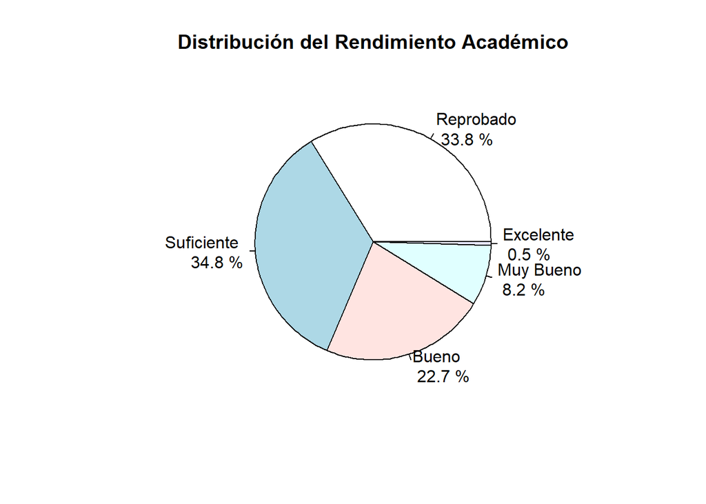

```r
datos$Rendimiento <- cut(datos$Nota_Final,
 breaks = c(0, 60, 70, 80, 90, 100),
 labels = c("Reprobado", "Suficiente", "Bueno", "Muy Bueno", "Excelente"),
 include.lowest = TRUE)

frecuencias <- table(datos$Rendimiento)
porcentajes <- round(prop.table(frecuencias) * 100, 1)
etiquetas <- paste(names(frecuencias), "\n", porcentajes, "%")

pie(frecuencias, labels = etiquetas,
 main = "Distribución del Rendimiento Académico")
```

### Actividad

Se debe observar el grafico de pastel y responder:

1. ¿Cual es la categorıa con mas estudiantes?

La categoría con más estudiantes es “Suficiente” (34.8 %)

2. ¿Que porcentaje de estudiantes reprobo?

El porcentaje de estudiantes que reprobó es 33.8 %.

## 7.2 Barras Horizontales

```r
datos$Nivel_Asistencia <- factor(
  cut(datos$Asistencia,
      breaks = c(0, 60, 75, 90, 100),
      labels = c("Bajo", "Regular", "Bueno", "Excelente"),
      include.lowest = TRUE),
  levels = c("Bajo", "Regular", "Bueno", "Excelente")
)

freq_asistencia <- table(datos$Nivel_Asistencia)

print(freq_asistencia)
```

```
##
##      Bajo   Regular     Bueno Excelente
##         5       218      1291       486
```

```r
# Para verlo más claro:
cat("Frecuencias por nivel:\n")
```

```
## Frecuencias por nivel:
```

```r
cat("Bajo:", freq_asistencia["Bajo"], "\n")
```

```
## Bajo: 5
```

```r
cat("Regular:", freq_asistencia["Regular"], "\n")
```

```
## Regular: 218
```

```r
cat("Bueno:", freq_asistencia["Bueno"], "\n")
```

```
## Bueno: 1291
```

```r
cat("Excelente:", freq_asistencia["Excelente"], "\n\n")
```

```
## Excelente: 486
```

```r
# Encontrar el nivel con menos estudiantes
cat("Nivel con menos estudiantes:", names(which.min(freq_asistencia)), "\n")
```

```
## Nivel con menos estudiantes: Bajo
```

```r
cat("Número de estudiantes con Excelente:", freq_asistencia["Excelente"])
```

```
## Número de estudiantes con Excelente: 486
```

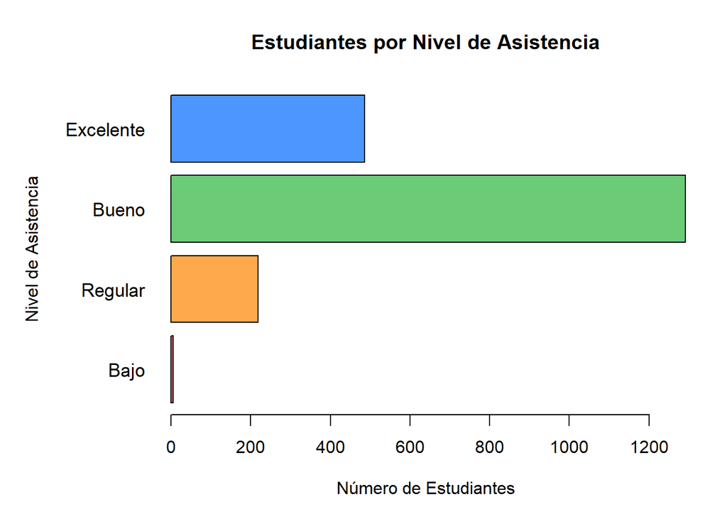

```r
par(mar = c(5, 8, 4, 2))
barplot(freq_asistencia,
        horiz = TRUE,
        col = c("#FF6B6B", "#FFA94D", "#6BCB77", "#4D96FF"),
        main = "Estudiantes por Nivel de Asistencia",
        xlab = "Número de Estudiantes",
        ylab = "",
        las = 1,
        cex.names = 1.1)

mtext("Nivel de Asistencia", side = 2, line = 6)
```

### Actividad

Se debe observar el grafico de barras y responder:

1. ¿Cuantos estudiantes tienen asistencia “Excelente”?

486 estudiantes tienen asistencia “Excelente”.

2. ¿Cual nivel de asistencia tiene menos estudiantes?

El nivel “Bajo” tiene menos estudiantes, con solo 5 estudiantes.

## 7.3 Boxplot

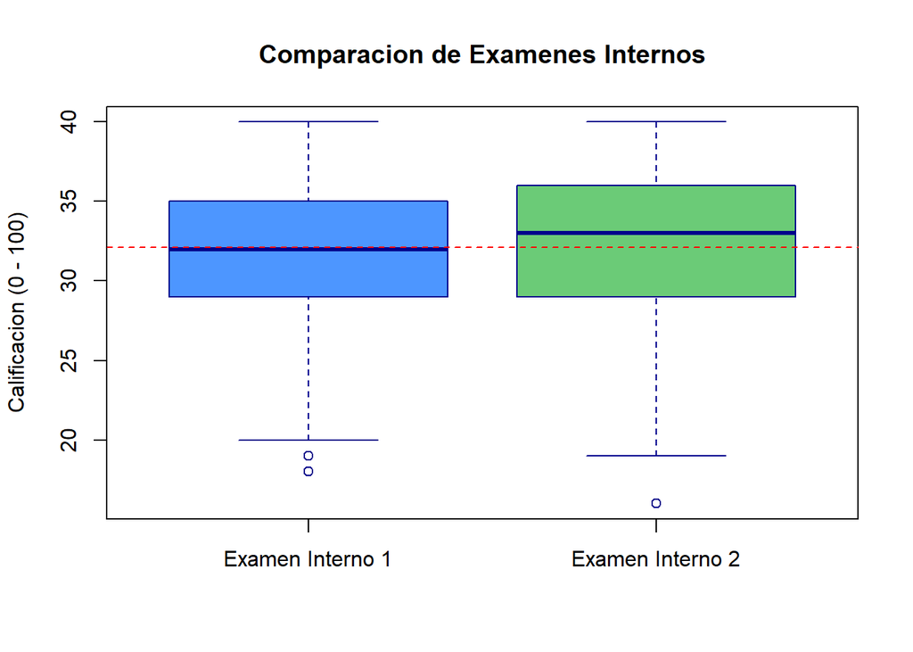

```r
# ================================
# DIAGRAMA DE CAJAS Y ESTADISTICAS
# EXAMENES INTERNOS 1 Y 2
# ================================

# Crear diagrama de cajas para ambos examenes internos
boxplot(
  datos$Examen_Interno_1,
  datos$Examen_Interno_2,
  names = c("Examen Interno 1", "Examen Interno 2"),
  col = c("#4D96FF", "#6BCB77"),
  main = "Comparacion de Examenes Internos",
  ylab = "Calificacion (0 - 100)",
  border = "darkblue"
)

# Agregar linea de la media del Examen 1
abline(h = mean(datos$Examen_Interno_1), col = "red", lty = 2)
```

```r
# ================================
# ESTADISTICAS EXAMEN INTERNO 1
# ================================
cat("=== EXAMEN INTERNO 1 ===\n")
```

```
## === EXAMEN INTERNO 1 ===
```

```r
cat("Media:", round(mean(datos$Examen_Interno_1), 2), "\n")
```

```
## Media: 32.12
```

```r
cat("Mediana:", round(median(datos$Examen_Interno_1), 2), "\n")
```

```
## Mediana: 32
```

```r
cat("Desv. Est.:", round(sd(datos$Examen_Interno_1), 2), "\n\n")
```

```
## Desv. Est.: 4.56
```

```r
# ================================
# ESTADISTICAS EXAMEN INTERNO 2
# ================================
cat("=== EXAMEN INTERNO 2 ===\n")
```

```
## === EXAMEN INTERNO 2 ===
```

```r
cat("Media:", round(mean(datos$Examen_Interno_2), 2), "\n")
```

```
## Media: 32.46
```

```r
cat("Mediana:", round(median(datos$Examen_Interno_2), 2), "\n")
```

```
## Mediana: 33
```

```r
cat("Desv. Est.:", round(sd(datos$Examen_Interno_2), 2), "\n")
```

```
## Desv. Est.: 4.52
```

### Actividad

Se deben comparar los dos examenes internos usando el boxplot y las estad´ısticas:

1. ¿Cual examen tiene la mediana mas alta?

El Examen Interno 2 presenta la mediana más alta, lo que indica que, en general, los estudiantes obtuvieron ligeramente mejores resultados en este examen en comparación con el Examen Interno 1.

2. ¿Cual examen tiene mayor dispersion (desviacion estandar)?

El Examen Interno 1 presenta una dispersión ligeramente mayor, ya que su desviación estándar es superior a la del Examen Interno 2. Esto indica que las calificaciones del Examen Interno 1 están un poco más dispersas respecto a su media.

# 7.4 Grafico de Violın

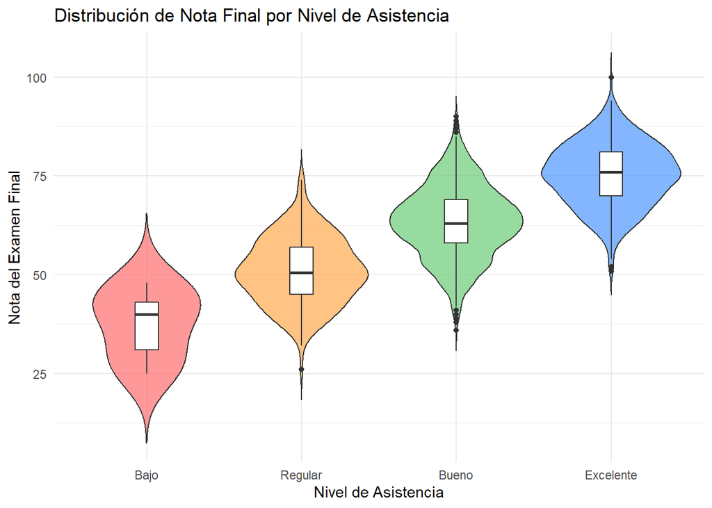

```r
# ================================
# CREAR GRÁFICO DE VIOLÍN
# ================================
ggplot(datos, aes(x = Nivel_Asistencia, y = Nota_Final, fill = Nivel_Asistencia)) +
  geom_violin(trim = FALSE, alpha = 0.7) +
  geom_boxplot(width = 0.15, fill = "white") +
  scale_fill_manual(values = c("#FF6B6B", "#FFA94D", "#6BCB77", "#4D96FF")) +
  labs(
    title = "Distribución de Nota Final por Nivel de Asistencia",
    x = "Nivel de Asistencia",
    y = "Nota del Examen Final"
  ) +
  theme_minimal() +
  theme(legend.position = "none")
```

### Actividad

Se debe observar el grafico de violın y responder:

1. ¿Cual nivel de asistencia muestra las notas mas altas?

El nivel de asistencia Excelente es el que muestra las notas finales más altas, ya que presenta las mayores concentraciones de datos en valores superiores (alrededor de 75 a 90 puntos), además de tener la mediana más elevada entre todos los grupos.

2. ¿Se observa alguna diferencia en la forma de las distribuciones?

Sí, se observan diferencias claras en la forma de las distribuciones. El nivel Bajo presenta una distribución concentrada en notas bajas, mientras que Regular se centra en valores intermedios. El nivel Bueno muestra una distribución más extendida hacia notas altas, y Excelente presenta una concentración claramente desplazada hacia los valores más altos del examen final. Esto evidencia una relación positiva entre el nivel de asistencia y el rendimiento académico.

# 8 Análisis de Normalidad

## 8.1 Histograma

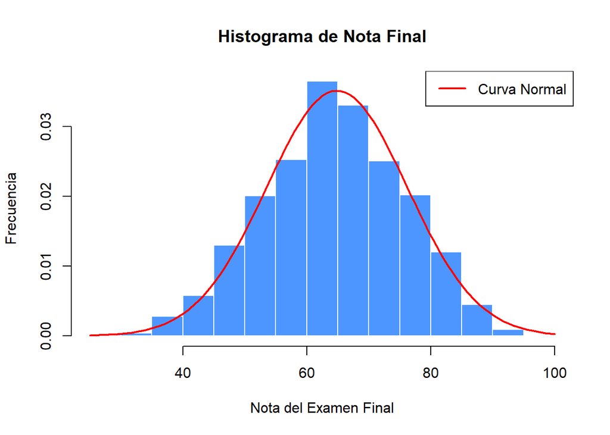

```r
# ================================
# CREAR HISTOGRAMA DE NOTA FINAL
# ================================
hist(
  datos$Nota_Final,
  breaks = 20,
  col = "#4D96FF",
  border = "white",
  main = "Histograma de Nota Final",
  xlab = "Nota del Examen Final",
  ylab = "Frecuencia",
  freq = FALSE  # Usar densidad en lugar de frecuencia
)

# ================================
# AGREGAR CURVA NORMAL TEÓRICA
# ================================
curve(
  dnorm(x, mean = mean(datos$Nota_Final), sd = sd(datos$Nota_Final)),
  add = TRUE,
  col = "red",
  lwd = 2
)

# ================================
# AGREGAR LEYENDA
# ================================
legend(
  "topright",
  legend = "Curva Normal",
  col = "red",
  lwd = 2
)
```

### Actividad

Se debe observar el histograma y responder:

1. ¿El histograma tiene forma de campana?

Sí, el histograma presenta una forma aproximada de campana, ya que la mayor concentración de datos se encuentra en el centro (alrededor de 60–70 puntos) y las frecuencias disminuyen gradualmente hacia ambos extremos. Además, la curva normal teórica se ajusta bastante bien a la forma del histograma.

## 8.2 Gráfico Q-Q

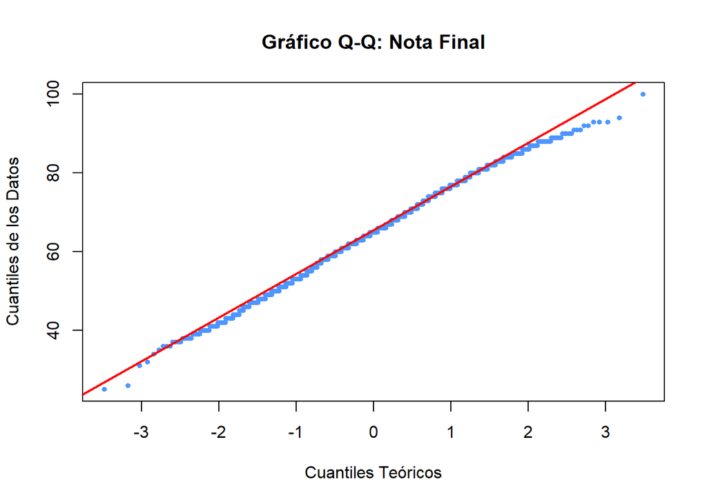

```r
# Crear gráfico Q-Q
qqnorm(datos$Nota_Final,
       main = "Gráfico Q-Q: Nota Final",
       xlab = "Cuantiles Teóricos",
       ylab = "Cuantiles de los Datos",
       col = "#4D96FF",
       pch = 19,
       cex = 0.6)

# Agregar línea de referencia
qqline(datos$Nota_Final, col = "red", lwd = 2)
```

### Actividad

¿Los puntos siguen la lınea roja?

Sí, los puntos siguen aproximadamente la línea roja a lo largo de la mayor parte de la distribución. Los puntos azules se alinean razonablemente bien con la diagonal roja, especialmente en la región central del gráfico.

¿Existen desviaciones en los extremos?

## 8.3 Pruebas

```r
# =============================================
# PRUEBA DE NORMALIDAD: SHAPIRO-WILK
# =============================================

# Prueba de Shapiro-Wilk
# NOTA: Esta prueba funciona mejor con menos de 5000 datos
shapiro_test <- shapiro.test(datos$Nota_Final)

cat("=== PRUEBA DE SHAPIRO-WILK ===\n")
```

```
## === PRUEBA DE SHAPIRO-WILK ===
```

```r
cat("Estadistico W:", round(shapiro_test$statistic, 4), "\n")
```

```
## Estadistico W: 0.9966
```

```r
cat("Valor p:", shapiro_test$p.value, "\n")
```

```
## Valor p: 0.0002190907
```

```r
# Interpretar resultado
if(shapiro_test$p.value > 0.05) {
  cat("Conclusion: Los datos SON NORMALES (p > 0.05)\n")
} else {
  cat("Conclusion: Los datos NO SON NORMALES (p <= 0.05)\n")
}
```

```
## Conclusion: Los datos NO SON NORMALES (p <= 0.05)
```

```r
# Prueba de Kolmogorov-Smirnov
# Primero se estandarizan los datos
datos_std <- (datos$Nota_Final - mean(datos$Nota_Final)) / sd(datos$Nota_Final)
ks_test <- ks.test(datos_std, "pnorm")
cat("=== PRUEBA DE KOLMOGOROV-SMIRNOV ===\n")
```

```
## === PRUEBA DE KOLMOGOROV-SMIRNOV ===
```

```r
cat("Estadistico D:", round(ks_test$statistic, 4), "\n")
```

```
## Estadistico D: 0.029
```

```r
cat("Valor p:", ks_test$p.value, "\n")
```

```
## Valor p: 0.06953239
```

```r
# Interpretar resultado
if(ks_test$p.value > 0.05) {
  cat("Conclusion: Los datos SON NORMALES (p > 0.05)\n")
} else {
  cat("Conclusion: Los datos NO SON NORMALES (p <= 0.05)\n")
}
```

```
## Conclusion: Los datos SON NORMALES (p > 0.05)
```

### Actividad

Se deben ejecutar las pruebas de normalidad y completar:

Prueba de Shapiro-Wilk:

Valor p=0.0002190907

p=0.0002190907

Conclusión: Los datos NO SON NORMALES (p ≤ 0.05)

Prueba de Kolmogorov-Smirnov: Valor p = 0.06953239

p=0.06953239

Conclusión: Los datos SON NORMALES (p > 0.05)

¿Los datos de Nota Final son normales?

Hay resultados contradictorios. Según Shapiro-Wilk no son normales, pero según Kolmogorov-Smirnov sí lo son.

# Visualizaciones Avanzadas

## 9 Correlación

```r
vars_numericas <- datos[, c("Asistencia", "Examen_Interno_1",
 "Examen_Interno_2", "Promedio_Tareas",
 "Horas_Estudio", "Nota_Final")]

matriz_cor <- cor(vars_numericas)
round(matriz_cor, 2)
```

```
##                  Asistencia Examen_Interno_1 Examen_Interno_2 Promedio_Tareas
## Asistencia             1.00             0.51             0.49            0.43
## Examen_Interno_1       0.51             1.00             0.26            0.57
## Examen_Interno_2       0.49             0.26             1.00            0.54
## Promedio_Tareas        0.43             0.57             0.54            1.00
## Horas_Estudio          0.30             0.21             0.23            0.17
## Nota_Final             0.73             0.69             0.69            0.67
##                  Horas_Estudio Nota_Final
## Asistencia                0.30       0.73
## Examen_Interno_1          0.21       0.69
## Examen_Interno_2          0.23       0.69
## Promedio_Tareas           0.17       0.67
## Horas_Estudio             1.00       0.41
## Nota_Final                0.41       1.00
```

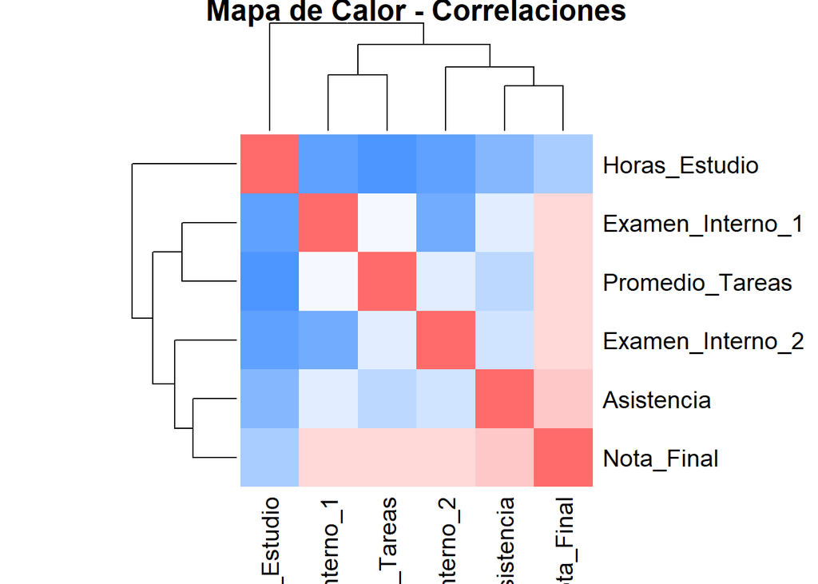

```r
heatmap(matriz_cor,
        col = colorRampPalette(c("#4D96FF", "white", "#FF6B6B"))(20),
        symm = TRUE,
        main = "Mapa de Calor - Correlaciones")
```

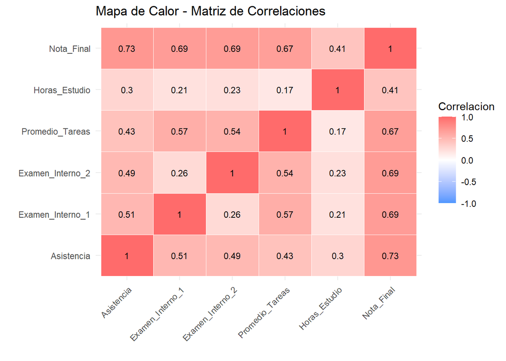

```r
# Instalar si es necesario: install.packages("reshape2")
library(reshape2)

# Convertir matriz a formato largo
matriz_largo <- melt(matriz_cor)
colnames(matriz_largo) <- c("Variable1", "Variable2", "Correlacion")

# Crear mapa de calor con ggplot2
ggplot(matriz_largo, aes(x = Variable1, y = Variable2, fill = Correlacion)) +
  geom_tile(color = "white") +
  geom_text(aes(label = round(Correlacion, 2)), size = 3) +
  scale_fill_gradient2(low = "#4D96FF", mid = "white", high = "#FF6B6B",
                       midpoint = 0, limit = c(-1, 1)) +
  labs(title = "Mapa de Calor - Matriz de Correlaciones",
       x = "", y = "") +
  theme_minimal() +
  theme(axis.text.x = element_text(angle = 45, hjust = 1))
```

# Grafico de Violın

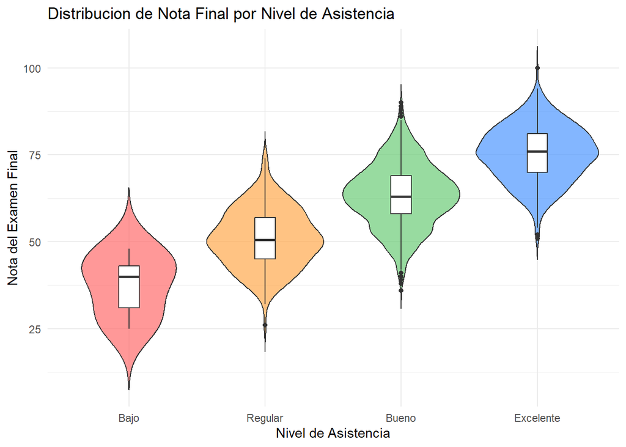

```r
ggplot(datos, aes(x = Nivel_Asistencia, y = Nota_Final, fill = Nivel_Asistencia)) +
  geom_violin(trim = FALSE, alpha = 0.7) +
  geom_boxplot(width = 0.15, fill = "white") +
  scale_fill_manual(values = c("#FF6B6B", "#FFA94D", "#6BCB77", "#4D96FF")) +
  labs(title = "Distribucion de Nota Final por Nivel de Asistencia",
       x = "Nivel de Asistencia",
       y = "Nota del Examen Final") +
  theme_minimal() +
  theme(legend.position = "none")
```

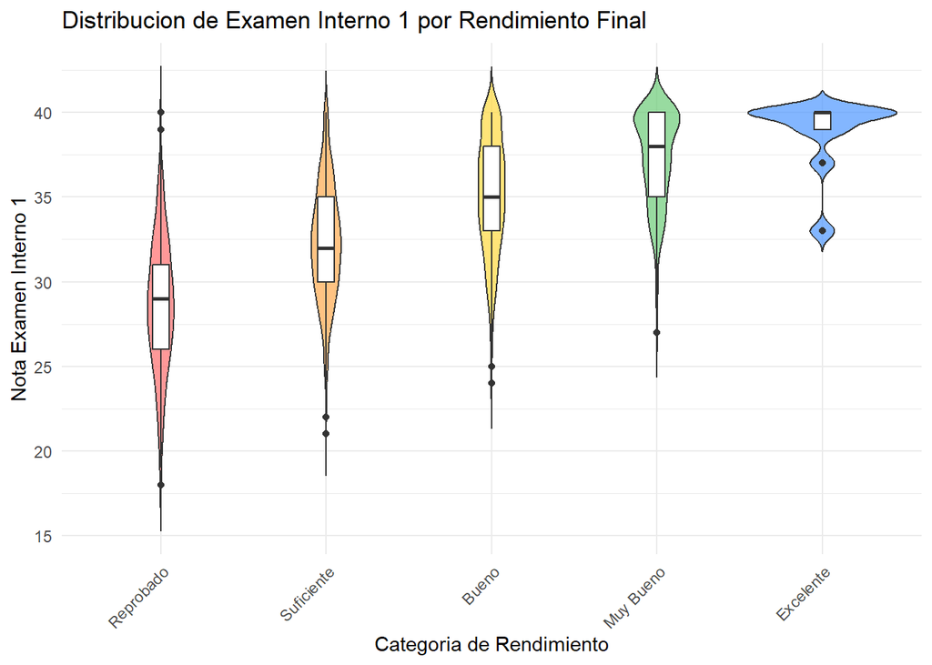

```r
# Grafico de violin por categoria de rendimiento
ggplot(datos, aes(x = Rendimiento, y = Examen_Interno_1, fill = Rendimiento)) +
  geom_violin(trim = FALSE, alpha = 0.7) +
  geom_boxplot(width = 0.1, fill = "white") +
  scale_fill_manual(values = c("#FF6B6B", "#FFA94D", "#FFD93D", "#6BCB77", "#4D96FF")) +
  labs(title = "Distribucion de Examen Interno 1 por Rendimiento Final",
       x = "Categoria de Rendimiento",
       y = "Nota Examen Interno 1") +
  theme_minimal() +
  theme(legend.position = "none",
        axis.text.x = element_text(angle = 45, hjust = 1))
```

### Actividad

Se debe observar el grafico de violın de Nota Final por Nivel de Asistencia y responder:

2. ¿En cual nivel de asistencia se observan las notas mas altas?

El nivel “Excelente” muestra las notas más altas, con la mediana y la mayoría de los valores en la parte superior del rango. También se observa que a medida que aumenta el nivel de asistencia (de Bajo a Excelente), la distribución de notas se desplaza hacia valores más altos.

3. ¿Que se puede concluir sobre la relaci´on entre asistencia y rendimiento?

Existe una relación positiva clara entre asistencia y rendimiento académico:

Los estudiantes con asistencia más baja tienden a tener notas más bajas y mayor variabilidad

Los estudiantes con asistencia más alta (Excelente) tienden a tener notas más altas y más consistentes

La mediana de las notas aumenta progresivamente con cada nivel de asistencia: Bajo < Regular < Bueno < Excelente

Conclusión general: La asistencia a clases es un fuerte predictor del rendimiento académico final, con estudiantes que asisten regularmente obteniendo mejores y más consistentes resultados.

# 10 Analisis de Correlacion

## 10.1 Mapa de Calor (Heatmap) de Correlaciones

```r
# Seleccionar solo variables numericas
vars_numericas <- datos[, c("Asistencia", "Examen_Interno_1",
                            "Examen_Interno_2", "Promedio_Tareas",
                            "Horas_Estudio", "Nota_Final")]

# Calcular matriz de correlacion
matriz_cor <- cor(vars_numericas)

# Mostrar la matriz
round(matriz_cor, 2)
```

```
##                  Asistencia Examen_Interno_1 Examen_Interno_2 Promedio_Tareas
## Asistencia             1.00             0.51             0.49            0.43
## Examen_Interno_1       0.51             1.00             0.26            0.57
## Examen_Interno_2       0.49             0.26             1.00            0.54
## Promedio_Tareas        0.43             0.57             0.54            1.00
## Horas_Estudio          0.30             0.21             0.23            0.17
## Nota_Final             0.73             0.69             0.69            0.67
##                  Horas_Estudio Nota_Final
## Asistencia                0.30       0.73
## Examen_Interno_1          0.21       0.69
## Examen_Interno_2          0.23       0.69
## Promedio_Tareas           0.17       0.67
## Horas_Estudio             1.00       0.41
## Nota_Final                0.41       1.00
```

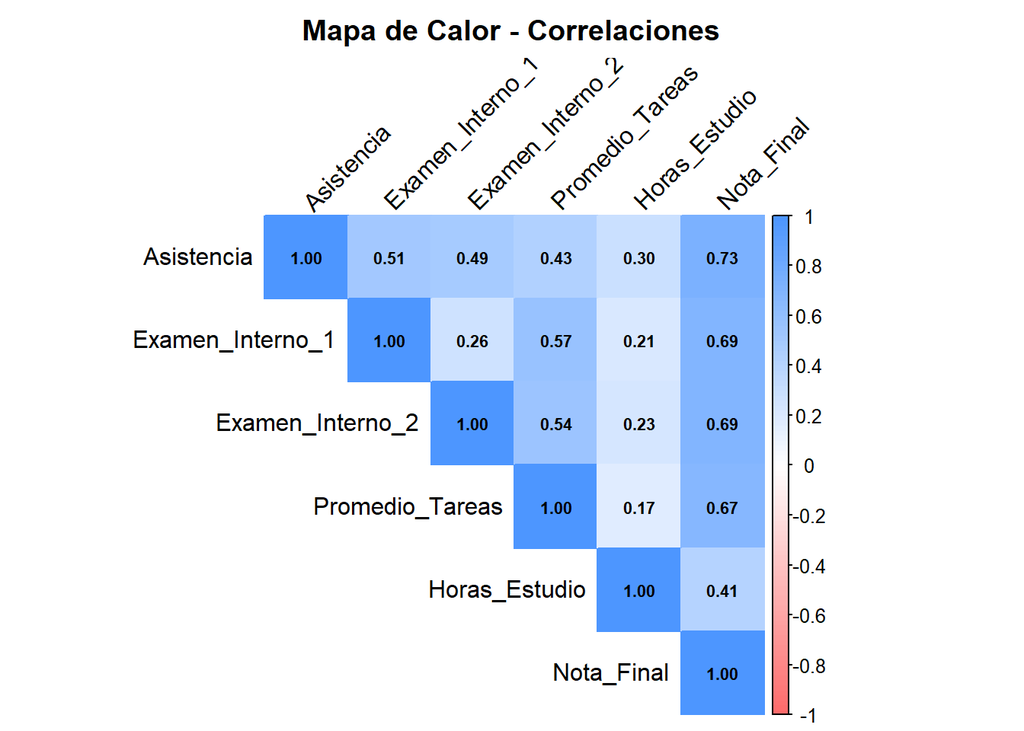

```r
# Mapa de calor con corrplot
corrplot(matriz_cor,
         method = "color",
         type = "upper",
         addCoef.col = "black",
         number.cex = 0.7,
         tl.col = "black",
         tl.srt = 45,
         col = colorRampPalette(c("#FF6B6B", "white", "#4D96FF"))(100),
         title = "Mapa de Calor - Correlaciones",
         mar = c(0, 0, 2, 0))
```

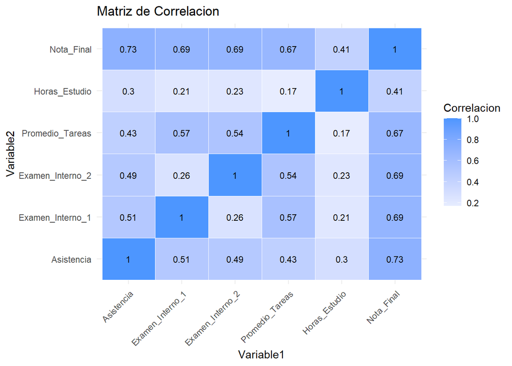

```r
# Convertir matriz a formato largo
matriz_largo <- melt(matriz_cor)
colnames(matriz_largo) <- c("Variable1", "Variable2", "Correlacion")

# Crear heatmap con ggplot2
ggplot(matriz_largo, aes(x = Variable1, y = Variable2, fill = Correlacion)) +
  geom_tile(color = "white") +
  geom_text(aes(label = round(Correlacion, 2)), size = 3) +
  scale_fill_gradient2(low = "#FF6B6B", mid = "white",
                       high = "#4D96FF", midpoint = 0) +
  labs(title = "Matriz de Correlacion") +
  theme_minimal() +
  theme(axis.text.x = element_text(angle = 45, hjust = 1))
```

Se debe observar el mapa de calor y responder:

1. ¿Cuales dos variables tienen la correlacion mas alta?

La correlación más alta entre variables diferentes es entre Asistencia y Nota_Final con un valor de 0.73. En segundo lugar están Examen_Interno_1 y Nota_Final (0.69) y Examen_Interno_2 y Nota_Final (0.69).

2. ¿Existe alguna correlacion negativa?

No, no existe ninguna correlación negativa en la matriz. Todos los valores son positivos, variando desde 0.17 hasta 1.00. El valor más bajo es entre Horas_Estudio y Promedio_Tareas (0.17).

3. ¿Que variable tiene la correlacion mas fuerte con Nota Final?

La Asistencia tiene la correlación más fuerte con Nota_Final, con un valor de 0.73. Esto indica una relación positiva fuerte: a mayor asistencia, mayor tiende a ser la nota final.

RESUMEN DE LAS CORRELACIONES CON NOTA_FINAL:

Asistencia: 0.73 (más fuerte)

Examen_Interno_1: 0.69

Examen_Interno_2: 0.69

Promedio_Tareas: 0.67

Horas_Estudio: 0.41 (más débil)

Interpretación: La asistencia a clases es el factor que muestra la relación más fuerte con el rendimiento académico final, seguido de cerca por los exámenes internos.

# 10.2 Grafico de Dispersion: Asistencia vs Nota Final

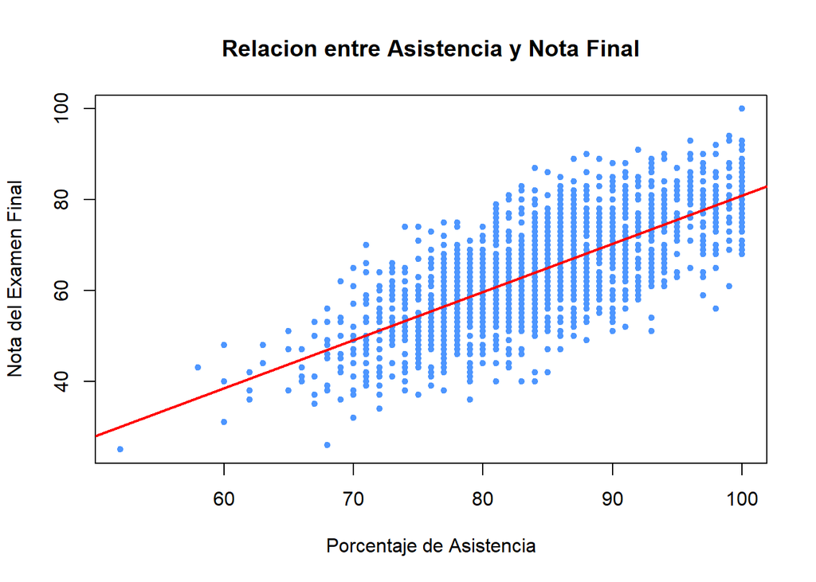

```r
plot(datos$Asistencia, datos$Nota_Final,
     main = "Relacion entre Asistencia y Nota Final",
     xlab = "Porcentaje de Asistencia",
     ylab = "Nota del Examen Final",
     col = "#4D96FF",
     pch = 19,
     cex = 0.7)

# Agregar linea de tendencia
abline(lm(Nota_Final ~ Asistencia, data = datos),
       col = "red",
       lwd = 2)
```

# 10.3 Calculo del Coeficiente de Correlacion

```r
# Calcular correlacion de Pearson
correlacion <- cor(datos$Asistencia, datos$Nota_Final)
cat("Coeficiente de correlacion (r):", round(correlacion, 4), "\n")
```

```
## Coeficiente de correlacion (r): 0.7256
```

```r
# Prueba de significancia
prueba_cor <- cor.test(datos$Asistencia, datos$Nota_Final)
cat("Valor p:", prueba_cor$p.value, "\n")
```

```
## Valor p: 0
```

```r
# Interpretar
if(prueba_cor$p.value < 0.05) {
  cat("La correlacion ES estadisticamente significativa\n")
} else {
  cat("La correlacion NO es significativa\n")
}
```

```
## La correlacion ES estadisticamente significativa
```

### Activadad

Se debe calcular la correlacion entre Asistencia y Nota Final:

Coeficiente r = 0.7256

Valor p = 0

Tipo de correlaci´on (fuerte/moderada/deebil): Fuerte

¿Es significativa? (Si / No): Si

# 11 Regresión Lineal

```r
modelo <- lm(Nota_Final ~ Asistencia, data = datos)
summary(modelo)
```

```
##
## Call:
## lm(formula = Nota_Final ~ Asistencia, data = datos)
##
## Residuals:
##      Min       1Q   Median       3Q      Max
## -23.9094  -5.4021   0.1196   5.4230  23.0906
##
## Coefficients:
##             Estimate Std. Error t value            Pr(>|t|)
## (Intercept) -25.1883     1.9181  -13.13 <0.0000000000000002 ***
## Asistencia    1.0607     0.0225   47.14 <0.0000000000000002 ***
## ---
## Signif. codes:  0 '***' 0.001 '**' 0.01 '*' 0.05 '.' 0.1 ' ' 1
##
## Residual standard error: 7.806 on 1998 degrees of freedom
## Multiple R-squared:  0.5266, Adjusted R-squared:  0.5263
## F-statistic:  2222 on 1 and 1998 DF,  p-value: < 0.00000000000000022
```

```r
# Obtener coeficientes
intercepto <- coef(modelo)[1]
pendiente <- coef(modelo)[2]

cat("=== ECUACION DEL MODELO ===\n")
```

```
## === ECUACION DEL MODELO ===
```

```r
cat("Nota_Final =", round(intercepto, 2), "+",
    round(pendiente, 2), "* Asistencia\n\n")
```

```
## Nota_Final = -25.19 + 1.06 * Asistencia
```

```r
# Coeficiente de determinacion R^2
r_cuadrado <- summary(modelo)$r.squared
cat("R cuadrado (R^2):", round(r_cuadrado, 4), "\n")
```

```
## R cuadrado (R^2): 0.5266
```

```r
cat("Esto significa que la Asistencia explica el",
    round(r_cuadrado * 100, 1), "% de la variabilidad en la Nota Final\n")
```

```
## Esto significa que la Asistencia explica el 52.7 % de la variabilidad en la Nota Final
```

### Actividad

Se debe crear el modelo de regresi´on y completar:

Nota_Final = -25.19 + 1.06 × Asistencia

R cuadrado = 0.5266

Interpretación: La Asistencia explica el 52.7% de la variabilidad en la nota final.

# 11.3 Visualizar el Modelo de Regresion

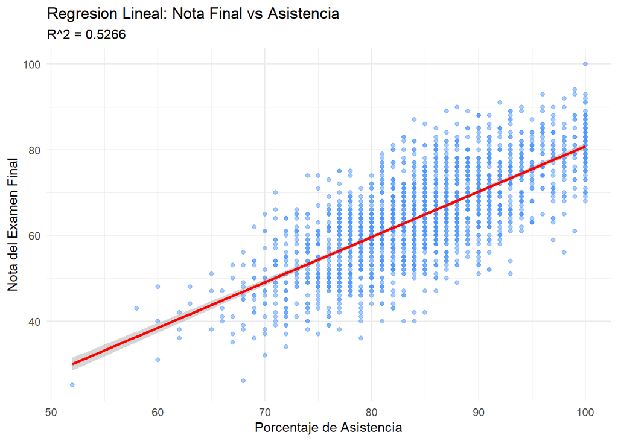

```r
ggplot(datos, aes(x = Asistencia, y = Nota_Final)) +
  geom_point(color = "#4D96FF", alpha = 0.5) +
  geom_smooth(method = "lm", color = "red", se = TRUE) +
  labs(
    title = "Regresion Lineal: Nota Final vs Asistencia",
    subtitle = paste("R^2 =", round(r_cuadrado, 4)),
    x = "Porcentaje de Asistencia",
    y = "Nota del Examen Final"
  ) +
  theme_minimal()
```

# 11.4 Realizar Predicciones

```r
# Crear datos para prediccion
nuevos_datos <- data.frame(
  Asistencia = c(60, 70, 80, 90, 100)
)

# Realizar predicciones
predicciones <- predict(modelo, newdata = nuevos_datos)

# Mostrar resultados
cat("=== PREDICCIONES ===\n")
```

```
## === PREDICCIONES ===
```

```r
for(i in 1:5) {
  cat("Si la asistencia es", nuevos_datos$Asistencia[i],
      "% -> Nota predicha:",
      round(predicciones[i], 1), "\n")
}
```

```
## Si la asistencia es 60 % -> Nota predicha: 38.5
## Si la asistencia es 70 % -> Nota predicha: 49.1
## Si la asistencia es 80 % -> Nota predicha: 59.7
## Si la asistencia es 90 % -> Nota predicha: 70.3
## Si la asistencia es 100 % -> Nota predicha: 80.9
```

### Actividad

Se debe usar el modelo para predecir la nota de un estudiante que tiene 85% de asistencia:

```r
# Predecir para 85% de asistencia
mi_prediccion <- data.frame(Asistencia = 85)
resultado <- predict(modelo, newdata = mi_prediccion)
cat("Nota predicha para 85% de asistencia:", round(resultado, 1), "\n")
```

```
## Nota predicha para 85% de asistencia: 65
```

La nota final predicha es de un 65.